# Project Python Foundations: FoodHub Data Analysis

#### **Question 8**: Which is the most popular cuisine on weekends? [1 mark]

```python
#filter for weekend by finding the value count of weekend and making the result of this a new df
weekend_df = df[df['day_of_the_week'] == 'Weekend']
weekend_df
# Count the occurrences of each cuisine type on the weekend
cuisine_counts = weekend_df['cuisine_type'].value_counts()
cuisine_counts
# Get the most popular cuisine on the weekend
most_popular_cuisine = cuisine_counts.idxmax() # get the name of the most popular cuisine
print('The most popular cuisine on the weekends is:',most_popular_cuisine)
most_popular_cuisine_count = cuisine_counts.max() # get the count of the most popular cuisine
print('with a total number of:',most_popular_cuisine_count)
```

```
The most popular cuisine on the weekends is: American
with a total number of: 415
```

##### **Observations:** The most poular cuisine on the weekend is the **American cuisine**, coming in at **415**. Here's the top 5:

1. American 415
2. Japanese 335
3. Italian 207
4. Chinese 163
5. Mexican 53

```python
df.loc[df['day_of_the_week'] == 'Weekend']['cuisine_type'].value_counts().head(5)
```

| cuisine_type | count |
| --- | --- |
| American | 415 |
| Japanese | 335 |
| Italian | 207 |
| Chinese | 163 |
| Mexican | 53 |

**dtype:** int64

#### **Question 9**: What percentage of the orders cost more than 20 dollars? [2 marks]

```python
# Find what percentage of the array is more than 20%
df_order_cost_gt_20 = df_oc_20 = df.loc[df['cost_of_the_order'] > 20].shape[0]
# Divide percentage by total data frame
df_oc_20_percentage = df_oc_20/df.shape[0] * 100
# Print statement
print(df_oc_20_percentage,'% of the orders cost more than $20')
```

```
29.24130663856691 % of the orders cost more than $20
```

##### **Observations**: 29.24% of the orders cost more than $ 20

#### **Question 10**: What is the mean order delivery time? [1 mark]

```python
# Find the average order delivery time
df['delivery_time'].mean()
```

```
24.161749209694417
```

##### **Observations**: The average order delivery time is 24 minutes.

#### **Question 11:** The company has decided to give 20% discount vouchers to the top 3 most frequent customers. Find the IDs of these customers and the number of orders they placed. [1 mark]

```python
# Find the Most Frequent Customers
most_frequent_customers = df['customer_id'].value_counts().sort_values(ascending=False).head(3) # get the top 3 most frequent customers
most_frequent_customers
print("The Most Frequent Customer ID's are:",most_frequent_customers)
```

```
The Most Frequent Customer ID's are: customer_id
52832    13
47440    10
83287     9
Name: count, dtype: int64
```

##### **Observations**: The Most Frequent Customer Ids are:

1. 52832
2. 47440
3. 83287

```python
# Find the number of orders placed by most frequent customers
df[df['customer_id'].isin(most_frequent_customers.index)].groupby('customer_id')['order_id'].count()
```

| customer_id | order_id |
| --- | --- |
| 47440 | 10 |
| 52832 | 13 |
| 83287 | 9 |

**dtype:** int64

## Multivariate Analysis

### **Question 12**: Perform a multivariate analysis to explore relationships between the important variables in the dataset. (It is a good idea to explore relations between numerical variables as well as relations between numerical and categorical variables) [10 marks]

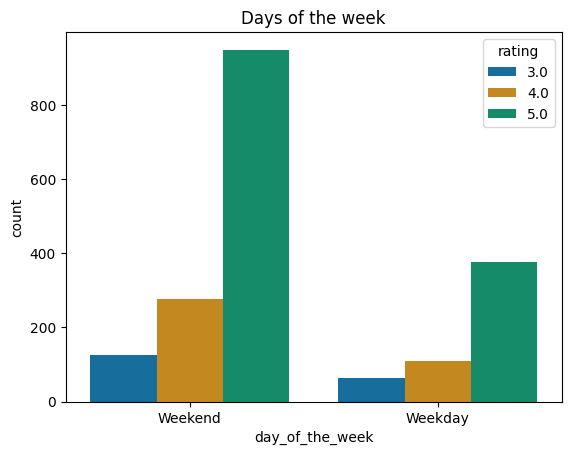

```python
sns.countplot(data=df,x='day_of_the_week',hue='rating', palette='colorblind').set_title('Days of the week')
plt.show()
```

Observation 1: **Days of the Week & Rating.**

I sought to find out if there is a correlation days of the week food is ordered on and the rating received. My observations are:

- On average, the weekend responses are greater than double that of the weekday responses.
- The highest received ratings in both Days of the Week are 5.0

Observation 2: **Delivery Time & Rating**

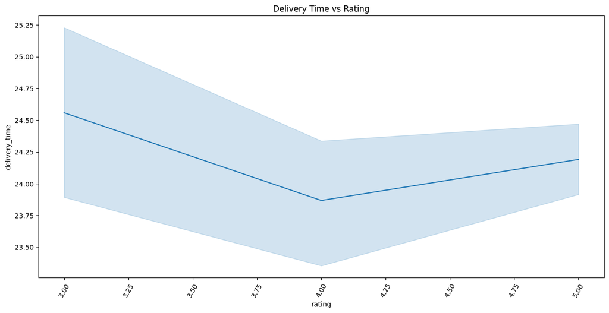

```python
# Delivery Time vs. Rating
plt.figure(figsize=(15,7))
sns.lineplot(x = "rating", y = "delivery_time", data = df, palette = 'PuBu')
plt.title('Delivery Time vs Rating')
plt.xticks(rotation = 60)
plt.show()
```

### **Question 13:** The company wants to provide a promotional offer in the advertisement of the restaurants. The condition to get the offer is that the restaurants must have a rating count of more than 50 and the average rating should be greater than 4. Find the restaurants fulfilling the criteria to get the promotional offer. [3 marks]

```python
# Locate and Sort Restaurants that have been rated
rating_counts = df.groupby(['restaurant_name'])['rating'].count().sort_values(ascending=False)
rating_counts
#Find the Restaurants with a rating count > 50 in top 10 descending order
df.groupby(['restaurant_name'])['rating'].count().sort_values(ascending=False).head(10)
top_10_restaurants = df.groupby(['restaurant_name'])['rating'].count().sort_values(ascending=False).head(10)
top_10_restaurants
```

| restaurant_name | rating |
| --- | --- |
| Shake Shack | 219 |
| The Meatball Shop | 132 |
| Blue Ribbon Sushi | 119 |
| Blue Ribbon Fried Chicken | 96 |
| Parm | 68 |
| RedFarm Broadway | 59 |
| RedFarm Hudson | 55 |
| TAO | 49 |
| Han Dynasty | 46 |
| Blue Ribbon Sushi Bar & Grill | 44 |

**dtype:** int64

```python
# Group by restaurant name and calculate ratings in descending order
average_rating_greater_than_4 = df.groupby(['restaurant_name'])['rating'].mean().sort_values(ascending=False)

# Filter the DataFrame using a boolean mask based on restaurant names
top_rated_restaurants = average_rating_greater_than_4[average_rating_greater_than_4 > 4].index
df_filtered = df[df['restaurant_name'].isin(top_rated_restaurants)]

df_filtered
```

|  | order_id | customer_id | restaurant_name | cuisine_type | cost_of_the_order | day_of_the_week | rating | food_preparation_time | delivery_time |
| --- | --- | --- | --- | --- | --- | --- | --- | --- | --- |
| 8 | 1477174 | 121706 | Anjappar Chettinad | Indian | 16.44 | Weekday | 5 | 21 | 26 |
| 9 | 1477311 | 39705 | Bukhara Grill | Indian | 7.18 | Weekday | 5 | 29 | 26 |
| 31 | 1477699 | 302790 | Klong | Thai | 29.05 | Weekend | 5 | 35 | 24 |
| 38 | 1477999 | 208020 | Haru Gramercy Park | Japanese | 29.83 | Weekday | 5 | 20 | 32 |
| 91 | 1477569 | 65009 | Chote Nawab | Indian | 16.15 | Weekend | 5 | 24 | 30 |
| 142 | 1477177 | 42385 | Song Thai Restaurant & Bar | Thai | 24.20 | Weekend | 5 | 21 | 26 |
| 240 | 1478227 | 367591 | Taro Sushi | Japanese | 16.05 | Weekday | 5 | 35 | 32 |
| 258 | 1478366 | 270149 | Samurai Mama | Japanese | 11.64 | Weekend | 5 | 21 | 18 |
| 429 | 1477278 | 347263 | Hummus Place | Middle Eastern | 16.15 | Weekend | 4 | 30 | 28 |
| 471 | 1478158 | 232035 | Balade | Middle Eastern | 9.22 | Weekday | 5 | 25 | 24 |
| 497 | 1477220 | 41249 | Kambi Ramen House | Japanese | 32.93 | Weekend | 5 | 35 | 19 |
| 517 | 1476916 | 52832 | Dickson's Farmstand Meats | American | 15.72 | Weekend | 4 | 23 | 28 |
| 587 | 1476669 | 142677 | Chola Eclectic Indian Cuisine | Indian | 8.73 | Weekend | 5 | 30 | 28 |
| 606 | 1477471 | 103147 | Hot Kitchen | Chinese | 29.54 | Weekend | 5 | 34 | 28 |
| 627 | 1478421 | 59673 | Dig Inn Seasonal Market | American | 15.71 | Weekday | 5 | 27 | 26 |
| 667 | 1476739 | 290266 | Socarrat Paella Bar | Spanish | 25.22 | Weekend | 5 | 23 | 20 |
| 689 | 1478151 | 62941 | Cipriani Le Specialita | Italian | 5.92 | Weekend | 5 | 35 | 30 |
| 871 | 1477046 | 302132 | Dos Caminos Soho | Mexican | 12.66 | Weekday | 5 | 24 | 30 |
| 884 | 1476646 | 103147 | Hot Kitchen | Chinese | 13.00 | Weekend | 5 | 32 | 25 |
| 919 | 1476622 | 399332 | Philippe Chow | Chinese | 24.20 | Weekday | 5 | 28 | 30 |
| 920 | 1477246 | 39705 | Bukhara Grill | Indian | 16.54 | Weekend | 5 | 23 | 17 |
| 1033 | 1476917 | 58675 | Big Daddy's | American | 14.84 | Weekend | 5 | 32 | 22 |
| 1065 | 1477035 | 141496 | Dickson's Farmstand Meats | American | 33.03 | Weekend | 5 | 35 | 20 |
| 1083 | 1476988 | 94115 | Moonstruck on Second | American | 14.94 | Weekend | 5 | 27 | 20 |
| 1126 | 1478345 | 365871 | Cafe de La Esquina | Mexican | 16.06 | Weekend | 5 | 27 | 21 |
| 1135 | 1478041 | 96456 | 67 Burger | American | 29.05 | Weekday | 5 | 20 | 28 |
| 1270 | 1478308 | 358158 | Galli Restaurant | Italian | 16.06 | Weekend | 5 | 22 | 16 |
| 1333 | 1477182 | 383826 | Song Thai Restaurant & Bar | Thai | 29.20 | Weekend | 5 | 21 | 28 |
| 1338 | 1477411 | 143721 | Hummus Place | Middle Eastern | 9.75 | Weekend | 5 | 28 | 28 |
| 1352 | 1477433 | 283331 | Dickson's Farmstand Meats | American | 12.18 | Weekend | 5 | 21 | 20 |
| 1404 | 1477962 | 59703 | Big Daddy's | American | 12.08 | Weekend | 5 | 22 | 16 |
| 1434 | 1476776 | 125123 | Le Grainne Cafe | French | 29.25 | Weekend | 5 | 27 | 24 |
| 1632 | 1476706 | 327651 | Hunan Manor | Chinese | 5.72 | Weekday | 5 | 31 | 26 |
| 1739 | 1477608 | 125123 | Le Grainne Cafe | French | 15.96 | Weekend | 4 | 25 | 22 |
| 1796 | 1478105 | 143721 | Hummus Place | Middle Eastern | 29.05 | Weekend | 5 | 26 | 17 |
| 1877 | 1478304 | 321492 | 'wichcraft | American | 8.10 | Weekday | 5 | 28 | 28 |

```python
#Apply the average ratings to the top 10 restaurants
top_rated_restaurants = average_rating[average_rating > 4.0]
top_rated_restaurants.head(10)
```

| restaurant_name | rating |
| --- | --- |
| 'wichcraft | 5.0 |
| Donburi-ya | 5.0 |
| Mission Cantina | 5.0 |
| Market Table | 5.0 |
| Le Zie 2000 Trattoria | 5.0 |
| Lantern Thai Kitchen | 5.0 |
| La Follia | 5.0 |
| Klong | 5.0 |
| Kanoyama | 5.0 |
| Kambi Ramen House | 5.0 |

**dtype:** float64

```python
# Find Restaurants with a rating average of greater than 5.0
df_rating_gt_5 = df.loc[df['rating'] > 5]
df_rating_gt_5
```

|  | order_id | customer_id | restaurant_name | cuisine_type | cost_of_the_order | day_of_the_week | rating | food_preparation_time | delivery_time |
| --- | --- | --- | --- | --- | --- | --- | --- | --- | --- |

### **Question 14:** The company charges the restaurant 25% on the orders having a cost greater than 20 dollars and 15% on the orders having a cost greater than 5 dollars. Find the net revenue generated by the company across all orders. [3 marks]

```python
# Define conditional statement
def calculate_revenue(cost):
    if cost > 20:
        return cost * 0.25
    elif cost > 5:
        return cost * 0.15
    else:
        return 0
# Apply the Function to the cost of the order and calculate the revenue
df['revenue'] = df['cost_of_the_order'].apply(calculate_revenue)

# Sum the total revenue
total_revenue = df['revenue'].sum()
print('The total revenue generated by the company across all orders is:',total_revenue)
```

```
The total revenue generated by the company across all orders is: 6166.303
```

##### **Observation**: The total revenue generated by the Foodhub company across all orders is: **$6166**

#### Observations:

### **Question 15:** The company wants to analyze the total time required to deliver the food. What percentage of orders take more than 60 minutes to get delivered from the time the order is placed? (The food has to be prepared and then delivered.) [2 marks]

```python
# Find the sum of Food Preparation and Food Delivery
df['total_time_taken'] = (df['food_preparation_time'] + df['delivery_time'])
df['total_time_taken']
# Find count of total Orders over 60 mins
df_total_time_gt_60 = df.loc[df['total_time_taken'] > 60].shape[0]
print(df_total_time_gt_60)
# Find percentage of total Orders over 60 mins
df_total_time_gt_60_percentage = df_total_time_gt_60/df.shape[0] * 100
# Print statement
print(df_total_time_gt_60_percentage,'% of orders take more than 60 minutes to get delivered')
```

```
200
10.537407797681771 % of orders take more than 60 minutes to get delivered
```

### **Question 16:** The company wants to analyze the delivery time of the orders on weekdays and weekends. How does the mean delivery time vary during weekdays and weekends? [2 marks]

```python
# Analyze Order Delivery Time by Day of the Week
df_weekday=df[df['day_of_the_week']=='Weekday']
df_weekend=df[df['day_of_the_week']=='Weekend']
# Mean Delivery Time on Weekday
df_weekday['delivery_time'].mean()
# Mean Delivery Time on Weekend
df_weekend['delivery_time'].mean()

# Print Statements
print('The mean delivery time on weekdays is:',df_weekday['delivery_time'].mean())
print('The mean delivery time on weekends is:',df_weekend['delivery_time'].mean())
```

```
The mean delivery time on weekdays is: 28.340036563071298
The mean delivery time on weekends is: 22.4700222057735
```

##### **Observations**:

The difference between the mean delivery time on weekdays and weekends is roughly *6 minutes*. It is **more** on the weekdays than it is on the weekends.

I would assume factors not present in the data set are responsible. Namely time of day, traffic congestion, etc.

## Conclusion and Recommendations

### **Question 17:** What are your conclusions from the analysis? What recommendations would you like to share to help improve the business? (You can use cuisine type and feedback ratings to drive your business recommendations.) [6 marks]

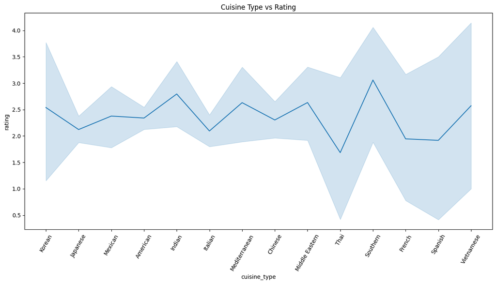

```python
# Make a category list for Cuisine Type, Rating by Restaurant name
df_cuisine_rating = df.groupby(['restaurant_name','cuisine_type'])['rating'].mean()
df_cuisine_rating
# Find the highest rated cuisine types by restaurant
df_cuisine_rating.sort_values(ascending=False).head(10)

plt.figure(figsize=(15,7))
sns.lineplot(x = "cuisine_type", y = "rating", data = df,)
plt.title('Cuisine Type vs Rating')
plt.xticks(rotation = 60)
plt.show()
```

#### Conclusions:

[output not shown]

#### Recommendations:

- Most orders cost about 13 dollars making the dishes in this price range critical to promote when displaying a not so popular restaurant, to incentivize new patronage on the app/platform.
- Another recommendation would be to incentivize user feedback through promotions & discounts using loyalty programs to increase participation and reviews.
- I recommend incentives to drivers and restaurants on the app to complete orders within a timeframe shorter than <40 minutes to increase customer retention.